# Scaling E-commerce operations in emerging markets: Brazilian SMEs

## Phase 3: Strategic Business Intelligence Analysis

It's time to go deeper in the analysis with some Business Intelligence findings, on:

- Customer Lifecycle & Retention
- Product Strategy & Revenue Optimization
- Predictive Analytics
- Performance Correlations

### Customer Lifecycle & Retention

#### Time Between Orders (TBO)

Mean time between first and second order for returning customers, and pattern identification for churn prediction

```
[1] "=== CUSTOMER ORDERS DEBUG ==="
[1] "Total customers: 95420"
[1] "Customers with multiple orders: 2085"
[1] "=== TIME BETWEEN ORDERS ANALYSIS ==="
# A tibble: 1 × 5
  mean_tbo median_tbo sd_tbo returning_customers total_intervals
     <dbl>      <dbl>  <dbl>               <int>           <int>
1     107.         64   113.                2085            2391
```

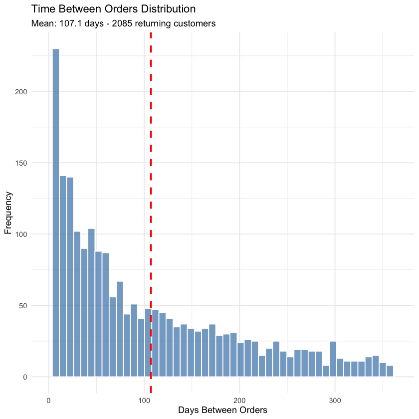

```r
customer_orders <- merged_table %>%
  filter(!is.na(order_purchase_timestamp)) %>%
  group_by(customer_unique_id) %>%
  arrange(order_purchase_timestamp) %>%
  summarise(
    first_order = min(as.Date(order_purchase_timestamp)),
    last_order = max(as.Date(order_purchase_timestamp)),
    total_orders = n_distinct(order_id),
    unique_order_dates = n_distinct(as.Date(order_purchase_timestamp)),
    .groups = 'drop'
  ) %>%
  filter(total_orders > 1, unique_order_dates > 1) # Need multiple distinct order dates

print("=== CUSTOMER ORDERS DEBUG ===")
print(paste("Total customers:", n_distinct(merged_table$customer_unique_id)))
print(paste("Customers with multiple orders:", nrow(customer_orders)))

# Only proceed if we have returning customers
if(nrow(customer_orders) > 0) {

  # Calculate actual time between orders
  customer_tbo <- merged_table %>%
    filter(customer_unique_id %in% customer_orders$customer_unique_id) %>%
    select(customer_unique_id, order_id, order_purchase_timestamp) %>%
    distinct() %>%
    arrange(customer_unique_id, order_purchase_timestamp) %>%
    group_by(customer_unique_id) %>%
    mutate(
      order_date = as.Date(order_purchase_timestamp),
      prev_order_date = lag(order_date),
      days_between = as.numeric(order_date - prev_order_date)
    ) %>%
    filter(!is.na(days_between)) %>%
    ungroup()

} else {
  print("=== NO RETURNING CUSTOMERS FOUND ===")
  print("This dataset appears to have mostly one-time customers")

  # Alternative: Show order frequency distribution
  order_frequency <- merged_table %>%
    group_by(customer_unique_id) %>%
    summarise(orders = n_distinct(order_id), .groups = 'drop') %>%
    count(orders, name = "customers")

  print("Order frequency distribution:")
  print(order_frequency)

  customer_tbo <- data.frame() # Empty dataframe
}

# TBO Distribution Analysis - Only if we have data
if(nrow(customer_tbo) > 0) {

  tbo_summary <- customer_tbo %>%
    summarise(
      mean_tbo = mean(days_between, na.rm = TRUE),
      median_tbo = median(days_between, na.rm = TRUE),
      sd_tbo = sd(days_between, na.rm = TRUE),
      returning_customers = n_distinct(customer_unique_id),
      total_intervals = n(),
      .groups = 'drop'
    )

  print("=== TIME BETWEEN ORDERS ANALYSIS ===")
  print(tbo_summary)

  # TBO histogram
  tbo_histogram <- ggplot(customer_tbo, aes(x = days_between)) +
    geom_histogram(bins = 50, fill = "steelblue", alpha = 0.7, color = "white") +
    geom_vline(aes(xintercept = mean(days_between)), color = "red", linetype = "dashed", size = 1) +
    labs(
      title = "Time Between Orders Distribution",
      subtitle = paste("Mean:", round(tbo_summary$mean_tbo, 1), "days -", tbo_summary$returning_customers, "returning customers"),
      x = "Days Between Orders",
      y = "Frequency"
    ) +
    theme_minimal() +
    scale_x_continuous(limits = c(0, 365))

  print(tbo_histogram)

} else {
  print("Skipping TBO histogram - no returning customers found")
}
```

#### Churn Rate Analysis

Market churn rate analysis and positioning companies in churn-rate vs reviews matrix

```
[1] "=== CHURN RATE ANALYSIS ==="
# A tibble: 3 × 5
  customer_segment customers churned_customers churn_rate avg_revenue
  <chr>                <int>             <dbl>      <dbl>       <dbl>
1 Frequent                48                16       33.3        779.
2 Occasional            2865              1660       57.9        303.
3 One-time             92507             56046       60.6        161.
```

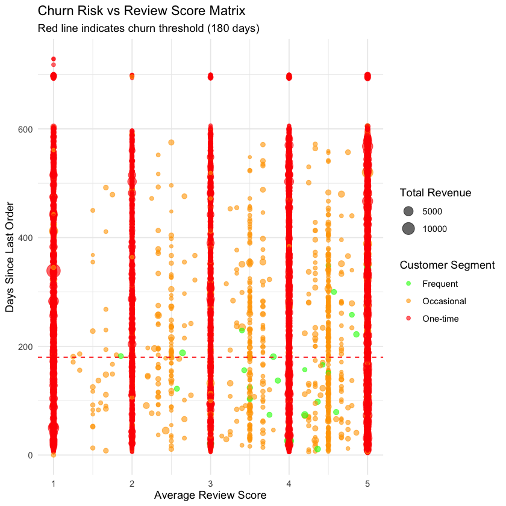

```r
# Define churn threshold (customers who haven't ordered in last 6 months)
analysis_date <- max(as.Date(merged_table$order_purchase_timestamp), na.rm = TRUE)
churn_threshold_days <- 180

# Customer churn analysis
customer_churn <- merged_table %>%
  group_by(customer_unique_id) %>%
  summarise(
    last_order_date = max(as.Date(order_purchase_timestamp), na.rm = TRUE),
    total_orders = n_distinct(order_id),
    total_revenue = sum(price + freight_value, na.rm = TRUE),
    avg_review_score = mean(review_score, na.rm = TRUE),
    .groups = 'drop'
  ) %>%
  mutate(
    days_since_last_order = as.numeric(analysis_date - last_order_date),
    is_churned = ifelse(days_since_last_order > churn_threshold_days, 1, 0),
    customer_segment = case_when(
      total_orders == 1 ~ "One-time",
      total_orders <= 3 ~ "Occasional",
      TRUE ~ "Frequent"
    )
  )

# Churn rate by segment
churn_rates <- customer_churn %>%
  group_by(customer_segment) %>%
  summarise(
    customers = n(),
    churned_customers = sum(is_churned),
    churn_rate = churned_customers / customers * 100,
    avg_revenue = mean(total_revenue),
    .groups = 'drop'
  )

print("=== CHURN RATE ANALYSIS ===")
print(churn_rates)

# Churn vs Reviews Matrix
churn_reviews_matrix <- ggplot(customer_churn %>% filter(!is.na(avg_review_score)),
                               aes(x = avg_review_score, y = days_since_last_order)) +
  geom_point(aes(color = customer_segment, size = total_revenue), alpha = 0.6) +
  geom_hline(yintercept = churn_threshold_days, color = "red", linetype = "dashed") +
  scale_color_manual(values = c("One-time" = "red", "Occasional" = "orange", "Frequent" = "green")) +
  labs(
    title = "Churn Risk vs Review Score Matrix",
    subtitle = "Red line indicates churn threshold (180 days)",
    x = "Average Review Score",
    y = "Days Since Last Order",
    color = "Customer Segment",
    size = "Total Revenue"
  ) +
  theme_minimal()

print(churn_reviews_matrix)
```

#### Customer Segmentation

RFM analysis and behavioral segmentation

```
[1] "=== RFM CUSTOMER SEGMENTATION ==="
# A tibble: 6 × 6
  rfm_segment        customers avg_recency avg_frequency avg_monetary percentage
  <chr>                  <int>       <dbl>         <dbl>        <dbl>      <dbl>
1 Potential Loyalis…     48341       243.            1            140       50.7
2 Loyal Customers        14500       158.            1.1          207       15.2
3 At Risk                13492       400.            1.1          246       14.1
4 Champions               6628        96.2           1.2          315        6.9
5 Lost Customers          6475       402.            1             56        6.8
6 New Customers           5984        95.4           1             55        6.3
```

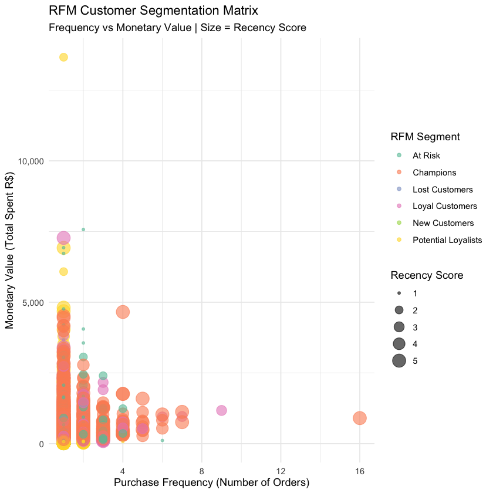

```r
# RFM Analysis - Recency, Frequency, Monetary
rfm_analysis <- merged_table %>%
  group_by(customer_unique_id) %>%
  summarise(
    recency = as.numeric(analysis_date - max(as.Date(order_purchase_timestamp), na.rm = TRUE)),
    frequency = n_distinct(order_id),
    monetary = sum(price + freight_value, na.rm = TRUE),
    .groups = 'drop'
  )

# Create RFM scores (1-5 scale)
rfm_scores <- rfm_analysis %>%
  mutate(
    r_score = ntile(-recency, 5),  # Lower recency = higher score
    f_score = ntile(frequency, 5),
    m_score = ntile(monetary, 5),
    rfm_score = paste0(r_score, f_score, m_score),
    rfm_segment = case_when(
      r_score >= 4 & f_score >= 4 & m_score >= 4 ~ "Champions",
      r_score >= 3 & f_score >= 3 & m_score >= 3 ~ "Loyal Customers",
      r_score >= 4 & f_score <= 2 & m_score <= 2 ~ "New Customers",
      r_score <= 2 & f_score >= 3 & m_score >= 3 ~ "At Risk",
      r_score <= 2 & f_score <= 2 & m_score <= 2 ~ "Lost Customers",
      TRUE ~ "Potential Loyalists"
    )
  )

# RFM Segment Summary
rfm_summary <- rfm_scores %>%
  group_by(rfm_segment) %>%
  summarise(
    customers = n(),
    avg_recency = round(mean(recency), 1),
    avg_frequency = round(mean(frequency), 1),
    avg_monetary = round(mean(monetary), 0),
    percentage = round(n() / nrow(rfm_scores) * 100, 1),
    .groups = 'drop'
  ) %>%
  arrange(desc(customers))

print("=== RFM CUSTOMER SEGMENTATION ===")
print(rfm_summary)

# RFM Scatter Plot Matrix
rfm_scatter_matrix <- ggplot(rfm_scores, aes(x = frequency, y = monetary)) +
  geom_point(aes(color = rfm_segment, size = r_score), alpha = 0.6) +
  scale_color_brewer(type = "qual", palette = "Set2") +
  scale_y_continuous(labels = scales::comma) +
  labs(
    title = "RFM Customer Segmentation Matrix",
    subtitle = "Frequency vs Monetary Value | Size = Recency Score",
    x = "Purchase Frequency (Number of Orders)",
    y = "Monetary Value (Total Spent R$)",
    color = "RFM Segment",
    size = "Recency Score"
  ) +
  theme_minimal()

print(rfm_scatter_matrix)
```

### Product Strategy & Revenue Optimization

#### Cross-selling Analysis

Product correlation and recommendation engine development

```r
order_products <- merged_table %>%
  select(order_id, product_category_name) %>%
  filter(!is.na(product_category_name)) %>%
  group_by(order_id) %>%
  summarise(categories = list(unique(product_category_name)), .groups = 'drop')

print("=== CROSS-SELLING DEBUG ===")
print(paste("Total orders:", nrow(order_products)))
print(paste("Orders with multiple categories:", sum(sapply(order_products$categories, length) > 1)))

# Only proceed if we have multi-category orders
multi_category_orders <- order_products %>%
  filter(sapply(categories, length) > 1)

if(nrow(multi_category_orders) > 0) {

  # Create transactions format
  transactions_list <- order_products$categories
  names(transactions_list) <- order_products$order_id

  # Convert to transactions object
  transactions <- as(transactions_list, "transactions")

  # Generate association rules
  rules <- apriori(transactions,
                  parameter = list(supp = 0.010, conf = 0.1, minlen = 2),
                  control = list(verbose = FALSE))

  if(length(rules) > 0) {
    # Get top rules
    top_rules <- head(sort(rules, by = "lift"), 10)

    print("=== TOP CROSS-SELLING RULES ===")
    inspect(top_rules)
  } else {
    print("=== NO ASSOCIATION RULES FOUND ===")
    print("Try lowering support or confidence thresholds")
  }

} else {
  print("=== NO MULTI-CATEGORY ORDERS FOUND ===")
  print("Each order contains only one product category")
}

# Alternative analysis: Simple category co-occurrence
print("=== SIMPLE CATEGORY CO-OCCURRENCE ===")
category_pairs <- merged_table %>%
  select(order_id, product_category_name) %>%
  filter(!is.na(product_category_name)) %>%
  group_by(order_id) %>%
  filter(n_distinct(product_category_name) > 1) %>%
  summarise(categories = list(sort(unique(product_category_name))), .groups = 'drop') %>%
  rowwise() %>%
  {
    # Create all combinations of categories within each order
    combinations <- list()
    for(i in 1:nrow(.)) {
      cats <- .$categories[[i]]
      if(length(cats) > 1) {
        combs <- combn(cats, 2, simplify = FALSE)
        combinations <- c(combinations, combs)
      }
    }

    # Convert to data frame
    if(length(combinations) > 0) {
      data.frame(
        cat1 = sapply(combinations, function(x) x[1]),
        cat2 = sapply(combinations, function(x) x[2])
      )
    } else {
      data.frame(cat1 = character(0), cat2 = character(0))
    }
  } %>%
  count(cat1, cat2, sort = TRUE) %>%
  head(20)

print("=== TOP CATEGORY COMBINATIONS ===")
print(category_pairs)
```

```
[1] "=== CROSS-SELLING DEBUG ==="
[1] "Total orders: 97256"
[1] "Orders with multiple categories: 726"
[1] "=== NO ASSOCIATION RULES FOUND ==="
[1] "Try lowering support or confidence thresholds"
[1] "=== SIMPLE CATEGORY CO-OCCURRENCE ==="
[1] "=== TOP CATEGORY COMBINATIONS ==="
                        cat1                  cat2  n
1             bed_bath_table       furniture_decor 70
2             bed_bath_table          home_confort 43
3            furniture_decor            housewares 24
4                       baby            cool_stuff 20
5             bed_bath_table            housewares 20
6                       baby                  toys 19
7                       baby        bed_bath_table 17
8            furniture_decor          garden_tools 17
9              health_beauty        sports_leisure 14
10           furniture_decor     home_construction 13
11                      baby       furniture_decor 12
12             health_beauty             perfumery 12
13            bed_bath_table         health_beauty 11
14 construction_tools_lights       furniture_decor 11
15              garden_tools            housewares 11
16                housewares        sports_leisure 11
17            bed_bath_table            cool_stuff 10
18     computers_accessories          garden_tools  9
19                cool_stuff                  toys  7
20           furniture_decor furniture_living_room  7
```

#### Value Ladder Analysis

Front-end vs back-end products analysis

```
[1] "=== VALUE LADDER ANALYSIS ==="
[1] "=== TOP ENTRY PRODUCTS (Customer Acquisition) ==="
# A tibble: 15 × 5
   product_category_name first_purchases avg_first_order_value
   <chr>                           <int>                 <dbl>
 1 bed_bath_table                   8861                 115.
 2 health_beauty                    8531                 156.
 3 sports_leisure                   7366                 139.
 4 computers_accessories            6435                 136.
 5 furniture_decor                  6057                 116.
 6 housewares                       5637                 118.
 7 watches_gifts                    5440                 226.
 8 telephony                        4094                  88.4
 9 auto                             3786                 164.
10 toys                             3755                 140.
11 cool_stuff                       3543                 193.
12 garden_tools                     3396                 147.
13 perfumery                        3061                 137.
14 baby                             2763                 164.
15 electronics                      2496                  74.7
# ℹ 2 more variables: customers_converted <int>, conversion_rate <dbl>
```

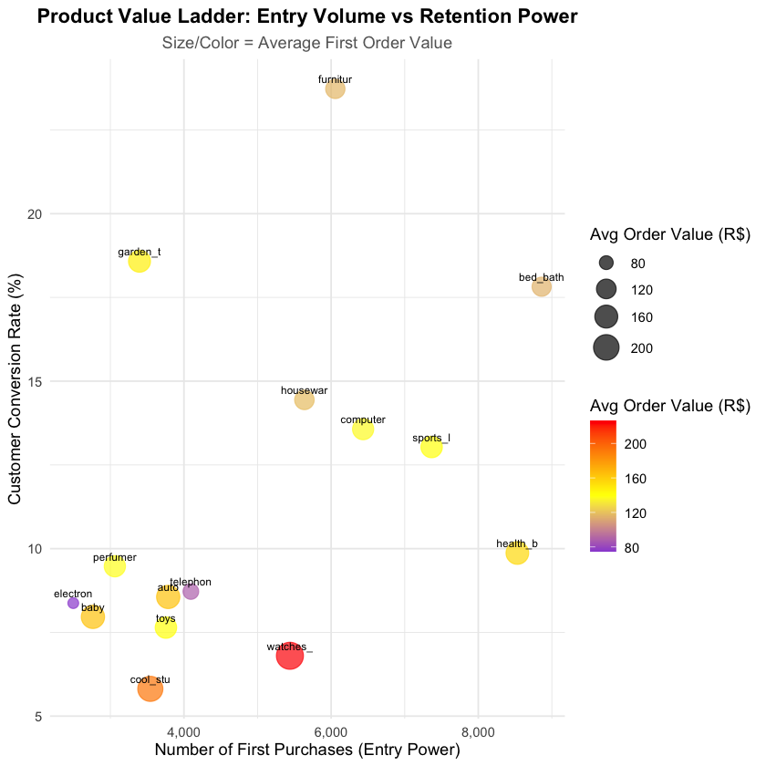

```r
# Value Ladder Analysis - IMPROVED VERSION
print("=== VALUE LADDER ANALYSIS ===")

# Analyze customer purchase patterns
customer_journey <- merged_table %>%
  arrange(customer_unique_id, order_purchase_timestamp) %>%
  group_by(customer_unique_id) %>%
  mutate(
    order_sequence = row_number(),
    is_first_purchase = order_sequence == 1,
    total_customer_orders = max(order_sequence)
  ) %>%
  ungroup()

# Entry products (what brings customers in)
entry_products <- customer_journey %>%
  filter(is_first_purchase) %>%
  group_by(product_category_name) %>%
  summarise(
    first_purchases = n(),
    avg_first_order_value = mean(price + freight_value, na.rm = TRUE),
    customers_converted = sum(total_customer_orders > 1),
    conversion_rate = customers_converted / first_purchases * 100,
    .groups = 'drop'
  ) %>%
  arrange(desc(first_purchases)) %>%
  head(15)

print("=== TOP ENTRY PRODUCTS (Customer Acquisition) ===")
print(entry_products)

# Value ladder visualization - Entry vs Retention Power
value_ladder_plot <- ggplot(entry_products,
                           aes(x = first_purchases, y = conversion_rate)) +
  geom_point(aes(color = avg_first_order_value, size = avg_first_order_value), alpha = 0.7) +
  geom_text(aes(label = substr(product_category_name, 1, 8)),
            vjust = -0.8, size = 2.5) +
  scale_color_gradient2(low = "blue", mid = "yellow", high = "red",
                       midpoint = median(entry_products$avg_first_order_value)) +
  scale_size_continuous(range = c(3, 8)) +
  scale_x_continuous(labels = scales::comma_format()) +
  labs(
    title = "Product Value Ladder: Entry Volume vs Retention Power",
    subtitle = "Size/Color = Average First Order Value",
    x = "Number of First Purchases (Entry Power)",
    y = "Customer Conversion Rate (%)",
    color = "Avg Order Value (R$)",
    size = "Avg Order Value (R$)"
  ) +
  theme_minimal() +
  theme(
    plot.title = element_text(hjust = 0.5, face = "bold"),
    plot.subtitle = element_text(hjust = 0.5, color = "grey40")
  )

print(value_ladder_plot)
```

### Predictive Analytics

#### Sales Forecasting

Forecasting models based on historical data

```
[1] "=== TIME SERIES DATA CHECK ==="
[1] "Date range: 2016-09-01 to 2018-09-01"
[1] "Number of months: 24"
[1] "Last 6 months of data:"
# A tibble: 6 × 3
  order_month total_revenue total_orders
  <date>              <dbl>        <int>
1 2018-04-01       1159698.         6934
2 2018-05-01       1149782.         6853
3 2018-06-01       1022677.         6160
4 2018-07-01       1058728.         6273
5 2018-08-01       1003308.         6452
6 2018-09-01           166.            1
```

```
[1] "ARIMA Model: Series: revenue_ts "
```

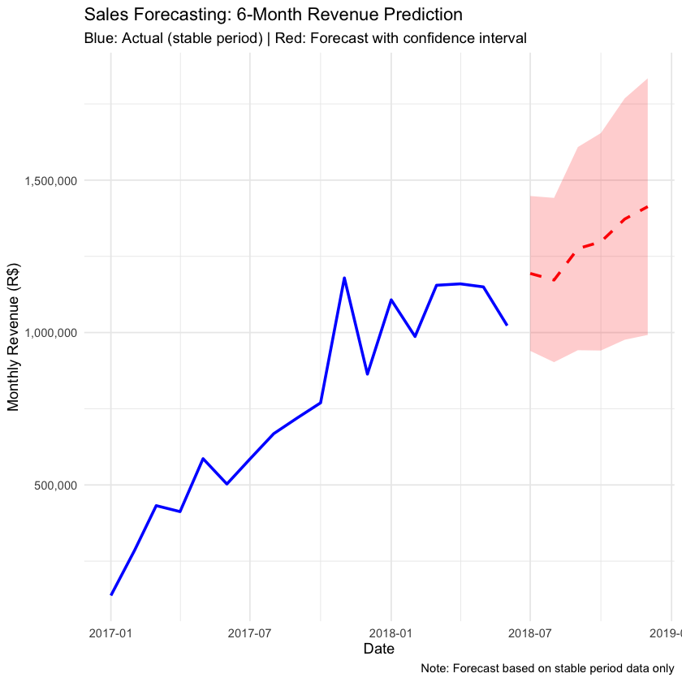

```r
# Prepare time series data
monthly_sales_ts <- merged_table %>%
  mutate(order_month = floor_date(as.Date(order_purchase_timestamp), "month")) %>%
  group_by(order_month) %>%
  summarise(
    total_revenue = sum(price + freight_value, na.rm = TRUE),
    total_orders = n_distinct(order_id),
    .groups = 'drop'
  ) %>%
  arrange(order_month) %>%
  filter(!is.na(order_month))

print("=== TIME SERIES DATA CHECK ===")
print(paste("Date range:", min(monthly_sales_ts$order_month), "to", max(monthly_sales_ts$order_month)))
print(paste("Number of months:", nrow(monthly_sales_ts)))
print("Last 6 months of data:")
print(tail(monthly_sales_ts, 6))

# Filter to stable period only (avoid dataset end effects)
stable_period <- monthly_sales_ts %>%
  filter(order_month >= as.Date("2017-01-01") & order_month <= as.Date("2018-06-01"))

if(nrow(stable_period) >= 12) {

  # Create time series object for stable period
  revenue_ts <- ts(stable_period$total_revenue,
                  frequency = 12,
                  start = c(year(min(stable_period$order_month)),
                           month(min(stable_period$order_month))))

  # Fit ARIMA model
  arima_model <- auto.arima(revenue_ts)
  forecast_result <- forecast(arima_model, h = 6) # 6 months ahead

} else {
  print("=== INSUFFICIENT DATA FOR RELIABLE FORECASTING ===")
  print("Dataset appears to be a sample period, not complete business history")
}

# Sales prediction visualization - only if we have forecast
if(exists("forecast_result")) {

  forecast_data <- data.frame(
    date = seq.Date(from = max(stable_period$order_month) + months(1),
                   by = "month", length.out = 6),
    forecast = as.numeric(forecast_result$mean),
    lower = as.numeric(forecast_result$lower[,2]),
    upper = as.numeric(forecast_result$upper[,2])
  )

  # Combine actual and forecast data
  actual_data <- stable_period %>%
    select(date = order_month, actual = total_revenue)

  forecast_plot_data <- full_join(actual_data, forecast_data, by = "date")

  sales_forecast_plot <- ggplot(forecast_plot_data, aes(x = date)) +
    geom_line(aes(y = actual), color = "blue", size = 1) +
    geom_line(aes(y = forecast), color = "red", size = 1, linetype = "dashed") +
    geom_ribbon(aes(ymin = lower, ymax = upper), alpha = 0.2, fill = "red") +
    labs(
      title = "Sales Forecasting: 6-Month Revenue Prediction",
      subtitle = "Blue: Actual (stable period) | Red: Forecast with confidence interval",
      x = "Date",
      y = "Monthly Revenue (R$)",
      caption = "Note: Forecast based on stable period data only"
    ) +
    scale_y_continuous(labels = scales::comma) +
    theme_minimal()

  print(sales_forecast_plot)
  print(paste("ARIMA Model:", capture.output(arima_model)[1]))

} else {
  # Alternative: Simple trend analysis
  print("=== SIMPLE TREND ANALYSIS ===")

  trend_plot <- ggplot(monthly_sales_ts, aes(x = order_month, y = total_revenue)) +
    geom_line(color = "steelblue", size = 1.2) +
    geom_smooth(method = "lm", color = "red", linetype = "dashed", se = TRUE) +
    labs(
      title = "Monthly Revenue Trend Analysis",
      subtitle = "Dataset shows limited time period - no reliable forecasting possible",
      x = "Date",
      y = "Monthly Revenue (R$)",
      caption = "Red line shows linear trend over available data"
    ) +
    scale_y_continuous(labels = scales::comma) +
    theme_minimal()

  print(trend_plot)
}
```